# Analysis

Team 20

11 November, 2021

```r
# load in all libraries
library(MLmetrics)
library(rpart)
library(sparsediscrim)
library(glmnet)
library(Hmisc)
library(forcats)
library(e1071)
library(Amelia)
library(Boruta)
library(mice)
library(tidyverse)
library(here)
library(readxl)
library(janitor)
library(stringr)
library(tidyr)
library(summarytools)
library(caret)
library(knitr)
library(naniar)
library(ggplot2)
library(GGally)
library(dplyr)
library(rpart)
library(rpart.plot)
library(kableExtra)
library(knitr)
library(devtools)
library(pheatmap)
library(viridis)
library(glmnet)
library(flextable)
library(Matrix)
library(kableExtra)
```

The research question we are aiming to answer is: **“Can we build a model based on age, gender, diet and lifestyle factors which predicts levels of cardiovascular risk?”**

We aim to try different models on the data to predict the levels of cardiovascular risk and find which model is the best. Then, with the final model, we decide whether it is possible to answer the research question. This is done, however, after we have completed data cleaning and data preprocessing to ensure that the model outcome is accurate and reliable enough to drive possible conclusions.

## Data Description

The provided data is from Australian Health Survey, National Health Survey 2011-2012, and National Nutrition and Physical Activity Survey 2011-2012. The data are divided into three datasets namely Biomedical Level Data items, Nutrient Level Data Items and Food Level Data Items. The information available includes household information, demographics, self-assessed measurements, food and nutrient intakes, physical activities, blood tests, and other relevant factors. The survey is based off the whole Australian population and people are free to decide whether to take the survey and conduct the health tests. There are 31,837 observations in total.

## Data cleaning

The raw data was first converted to technically correct data by cleaning and filling in the variable names to be human readable, removing empty rows and getting the correct data types for each variable. This **tech_data.Rdata** file is obtained from the STAT3888 coordinator’s cleaning code. Here, we imported the file as it is to maximise its usage before we continue to process the data to obtain consistent data that is suitable for further analysis, modelling and prediction.

```r
# load technically correct data
load("tech_data.Rdata")
```

## Calculating Framingham score

From the formula provided by the nutrition team, we used the technically correct data to calculate the Framingham score. The Framingham score is a cardiovascular disease risk assessment tool. The calculation includes an individual’s age, sex, total cholesterol level, HDL cholesterol level, systolic blood pressure, smoking status and diabetes status. Since the data available in our dataset is in ranges, we cannot calculate the score directly.

Instead, we calculated the CVD Points for men and women based on the score sheet provided that arranges individuals to different CVD points associated with different ranges of these factors included. Then, according to the study paper, we assigned the CVD Points to their corresponding risk percentage. With this, we classified the individuals into low, medium and high risk groups which will be easier for modelling.

Moreover, as there exist class imbalance due to majority of younger groups being in the low risk class, and according to recommendation of The Heart Foundation, we only included people with age greater than 45. This is the recommended age for the first heart check. Also, this provides a better class balance that prevents potential errors and problems that may occur in future modelling. It prevents the model from being inaccurate and biased.

When calculating the CVD Points, we had to perform several conditioning procedure to assign different points for different sex, age, tests results, smoking status and diabetes status.

```r
# calculate CVD Point for female and male
is_smoke = function(SMKSTAT) {
  if (SMKSTAT == 1 || SMKSTAT == 2 || SMKSTAT == 3) {
    # smoking
    return(1)
  }
  # not smoking
  return(0)
}

is_diabet = function(DIABBC) {
  if (DIABBC == 5) {
    # not diabetes
    return(0)
  }
  # diabetes
  return(1)
}

female_cvd_score = function(age, hdl, chol, sbp_t, sbp_nt, smoke, diabet) {

  score = 0

  if (is_smoke(smoke)) {
    score = score + 3
  }

  if (is_diabet(diabet)) {
    score = score + 4
  }

  if (35 <= age && age <= 39) {
    score = score + 2
  } else if (40 <= age && age <= 44) {
    score = score + 4
  } else if (45 <= age && age <= 49) {
    score = score + 5
  } else if (50 <= age && age <= 54) {
    score = score + 7
  } else if (55 <= age && age <= 59) {
    score = score + 8
  } else if (60 <= age && age <= 64) {
    score = score + 9
  } else if (65 <= age && age <= 69) {
    score = score + 10
  } else if (70 <= age && age <= 74) {
    score = score + 11
  } else if (age >= 75) {
    score = score + 12
  }

  if (hdl == 1 || hdl == 2 || hdl == 3) {
    score = score + 2
  } else if (hdl == 4) {
    score = score + 1
  }

  # problem: chol == 4, 8
  if (chol == 2 || chol == 3) {
    score = score + 1
  } else if (chol == 4) {
    score = score + 2
  } else if (chol == 5 || chol == 6) {
    score = score + 3
  } else if (chol == 7) {
    score = score + 4
  } else if (chol == 8) {
    score = score + 5
  }

  # SBP treated
  if (sbp_nt < 120) {
    score = score - 3
  } else if (120 <= sbp_nt && sbp_nt <= 129) {
    score = score
  } else if (130 <= sbp_nt && sbp_nt <= 139) {
    score = score + 1
  } else if (140 <= sbp_nt && sbp_nt <= 149) {
    score = score + 2
  } else if (150 <= sbp_nt && sbp_nt <= 159) {
    score = score + 4
  } else if (sbp_nt >= 160) {
    score = score + 5
  }

  if (sbp_t < 120) {
    score = score - 1
  } else if (120 <= sbp_t && sbp_t <= 129) {
    score = score + 2
  } else if (130 <= sbp_t && sbp_t <= 139) {
    score = score + 3
  } else if (140 <= sbp_t && sbp_t <= 149) {
    score = score + 5
  } else if (150 <= sbp_t && sbp_t <= 159) {
    score = score + 6
  } else if (sbp_t >= 160) {
    score = score + 7
  }

  return(score)
}

male_cvd_score = function(age, hdl, chol, sbp_t, sbp_nt, smoke, diabet) {

  score = 0

  if (is_smoke(smoke)) {
    score = score + 4
  }
  if (is_diabet(diabet)) {
    score = score + 3
  }

  if (35 <= age && age <= 39) {
    score = score + 2
  } else if (age <= 40 && age <= 44) {
    score = score + 5
  } else if (age <= 45 && age <= 49) {
    score = score + 6
  } else if (age <= 50 && age <= 54) {
    score = score + 8
  } else if (age <= 55 && age <= 59) {
    score = score + 10
  } else if (age <= 60 && age <= 64) {
    score = score + 11
  } else if (age <= 65 && age <= 69) {
    score = score + 12
  } else if (age <= 70 && age <= 74) {
    score = score + 14
  } else if (age >= 75) {
    score = score + 15
  }


  if (hdl == 1 || hdl == 2 || hdl == 3) {
    score = score + 2
  } else if (hdl == 4) {
    score = score + 1
  }

  # problem: chol == 4, 8
  if (chol == 2 || chol == 3 || chol == 4) {
    score = score + 1
  } else if (chol == 5 || chol == 6) {
    score = score + 2
  } else if (chol == 7) {
    score = score + 3
  } else if (chol == 8) {
    score = score + 4
  }

  # SBP treated
  if (sbp_nt < 120) {
    score = score - 2
  } else if (120 <= sbp_nt && sbp_nt <= 129) {
    score = score
  } else if (130 <= sbp_nt && sbp_nt <= 139) {
    score = score + 1
  } else if (140 <= sbp_nt && sbp_nt <= 159) {
    score = score + 2
  } else if (sbp_nt >= 160) {
    score = score + 3
  }

  if (sbp_t < 120) {
    score = score
  } else if (120 <= sbp_t && sbp_t <= 129) {
    score = score + 2
  } else if (130 <= sbp_t && sbp_t <= 139) {
    score = score + 3
  } else if (140 <= sbp_t && sbp_t <= 159) {
    score = score + 4
  } else if (sbp_t >= 160) {
    score = score + 5
  }

  return(score)
}


cvd_score = function(sex, age, hdl, chol, sbp_t, sbp_nt, smoke, diabet) {
  if (is.na(sex) || is.na(age) || is.na(hdl) || is.na(chol) || is.na(sbp_t) || is.na(sbp_nt) || is.na(smoke) || is.na(diabet))
    return(NA)
  if (sex == 1) {
    return(male_cvd_score(age, hdl, chol, sbp_t, sbp_nt, smoke, diabet))
  } else if (sex == 2) {
    return(female_cvd_score(age, hdl, chol, sbp_t, sbp_nt, smoke, diabet))
  }
}

cvd_wrapper = function(row) {
  score = cvd_score(row["SEX"], row["AGEC"], row["HDLCHREB"], row["CHOLRESB"], row["SYSTOL"], row["SYSTOL"], row["SMKSTAT"], row["DIABBC"])

  return(score)
}
```

```r
# copy technically correct biom dataset into dat
dat = tech_biom

# removing special values found in exercises variables
miss_defs <- c("9996", "9999")
dat <- dat %>%
  naniar::replace_with_na(replace = list(EXLWTBC = miss_defs))

dat$CVD_Point = apply(tech_biom, 1, cvd_wrapper)

# how many CVD Point available
# table(is.na(dat$CVD_Point))
```

```r
# assigning risk percentage to each CVD Point (sex-specific)
dat = dat %>% mutate(
  cvd_risk = case_when(
    SEX == 1 & CVD_Point <= -3 ~ 0,
    SEX == 1 & CVD_Point == -2 ~ 1.1,
    SEX == 1 & CVD_Point == -1 ~ 1.4,
    SEX == 1 & CVD_Point == 0 ~ 1.6,
    SEX == 1 & CVD_Point == 1 ~ 1.9,
    SEX == 1 & CVD_Point == 2 ~ 2.3,
    SEX == 1 & CVD_Point == 3 ~ 2.8,
    SEX == 1 & CVD_Point == 4 ~ 3.3,
    SEX == 1 & CVD_Point == 5 ~ 3.9,
    SEX == 1 & CVD_Point == 6 ~ 4.7,
    SEX == 1 & CVD_Point == 7 ~ 5.6,
    SEX == 1 & CVD_Point == 8 ~ 6.7,
    SEX == 1 & CVD_Point == 9 ~ 7.9,
    SEX == 1 & CVD_Point == 10 ~ 9.4,
    SEX == 1 & CVD_Point == 11 ~ 11.2,
    SEX == 1 & CVD_Point == 12 ~ 13.2,
    SEX == 1 & CVD_Point == 13 ~ 15.6,
    SEX == 1 & CVD_Point == 14 ~ 18.4,
    SEX == 1 & CVD_Point == 15 ~ 21.6,
    SEX == 1 & CVD_Point == 16 ~ 25.3,
    SEX == 1 & CVD_Point == 17 ~ 29.4,
    SEX == 1 & CVD_Point >= 18 ~ 30.0,

    SEX == 2 & CVD_Point <= -2 ~ 0,
    SEX == 2 & CVD_Point == -1 ~ 1.0,
    SEX == 2 & CVD_Point == 0 ~ 1.2,
    SEX == 2 & CVD_Point == 1 ~ 1.5,
    SEX == 2 & CVD_Point == 2 ~ 1.7,
    SEX == 2 & CVD_Point == 3 ~ 2.0,
    SEX == 2 & CVD_Point == 4 ~ 2.4,
    SEX == 2 & CVD_Point == 5 ~ 2.8,
    SEX == 2 & CVD_Point == 6 ~ 3.3,
    SEX == 2 & CVD_Point == 7 ~ 3.9,
    SEX == 2 & CVD_Point == 8 ~ 4.5,
    SEX == 2 & CVD_Point == 9 ~ 5.3,
    SEX == 2 & CVD_Point == 10 ~ 6.3,
    SEX == 2 & CVD_Point == 11 ~ 7.3,
    SEX == 2 & CVD_Point == 12 ~ 8.6,
    SEX == 2 & CVD_Point == 13 ~ 10.0,
    SEX == 2 & CVD_Point == 14 ~ 11.7,
    SEX == 2 & CVD_Point == 15 ~ 13.7,
    SEX == 2 & CVD_Point == 16 ~ 15.9,
    SEX == 2 & CVD_Point == 17 ~ 18.5,
    SEX == 2 & CVD_Point == 18 ~ 21.5,
    SEX == 2 & CVD_Point == 19 ~ 24.8,
    SEX == 2 & CVD_Point == 20 ~ 18.5,
    SEX == 2 & CVD_Point >= 21 ~ 30,
  )
)

# divide risk into three classes (low, medium, high)
dat = dat %>% mutate(cvd_class = case_when(
  cvd_risk > 19 ~ 3,
  cvd_risk < 10 ~ 1,
  cvd_risk >= 10 & cvd_risk <= 19 ~ 2))

# filter CVD class for age > 45
dat <- dat %>% filter(AGEC >= 45, !is.na(cvd_class))
dat$cvd_class <- as.factor(dat$cvd_class)
```

## Further processing of data

After calculating the CVD Points and obtaining the CVD classes, it is time to process the data to have it ready for analysis. Since we are analysing the possibility to predict the levels of risk using lifestyle factors, we need to use data from food dataset too. So, we selected only food variables that are in grams and took the median value of these variables for each individual.

```r
# extract variables in grams from food dataset and calculate the median for each individual
food_gram_cols <- na.omit(types_food[str_detect(types_food$description, "g$|\\(g\\)$"),]$variable_name)
food_gram_cols <- intersect(food_gram_cols, colnames(tech_food))
food_gram <- tech_food %>% select(ABSPID, all_of(food_gram_cols))
food_gram_median <- food_gram %>% group_by(ABSPID) %>% summarise_all(median)
```

Then, we joined the food dataset with the biom dataset for future use. As we only require age, gender, diet and lifestyle factors, the variables like the identification number and blood tests are removed. We have also removed redundant information and non-valuable information in our modelling.

```r
# join biom datasest and modified food dataset
biom_food_cleaned <- dat %>%
  left_join(food_gram_median, by = "ABSPID")

# remove redundant information, blood test variables and useless variables
biom_food_cleaned <- biom_food_cleaned %>%
  select(-c("ABSPID", "CVD_Point", "cvd_risk", "HCHOLBC", "HSUGBC", "HYPBC", "DIASTOL", "FEMLSBC", "ALTNTR", "ALTRESB", "APOBNTR","APOBRESB", "B12RESB", "BIORESPC", "CHOLNTR", "CHOLRESB", "CVDMEDST", "DIAHBRSK", "FASTSTAD", "FOLATREB", "GGTNTR", "GGTRESB", "HBA1PREB", "HDLCHREB", "LDLNTR", "LDLRESB", "TRIGNTR", "TRIGRESB", "SYSTOL", "GLUCFPD", "GLUCFREB" )) %>%
  select(-contains("MISS"))

# remove height and weight that is not needed
biom_food_cleaned <- biom_food_cleaned %>% select(-PHDKGWBC, -PHDCMHBC)
```

Furthermore, to improve the accuracy and precision of our analysis, we removed all constant and low variance variables. The variables with high missing rate and observations with NA values are also dropped.

```r
# remove constant variables
biom_food_cleaned <- biom_food_cleaned %>%
  remove_constant()

# remove low variance/near to zero variance variables
biom_food_cleaned <- biom_food_cleaned[-nearZeroVar(biom_food_cleaned)]

# visualize missing values in our complete joined dataset
miss_table <- miss_var_summary(biom_food_cleaned)
miss_table$pct_miss <- round(miss_table$pct_miss, 2)
DT::datatable(miss_table)
```

|  | variable | n_miss | pct_miss |
| --- | --- | --- | --- |
| 1 | DIETQ14 | 1060 | 45.53 |
| 2 | DIETQ12 | 1051 | 45.15 |
| 3 | INCDEC | 117 | 5.03 |
| 4 | BMISC | 65 | 2.79 |
| 5 | PHDCMWBC | 47 | 2.02 |
| 6 | EXLWTBC | 14 | 0.6 |
| 7 | ADTOTSE | 12 | 0.52 |
| 8 | SLPTIME | 5 | 0.21 |
| 9 | BDYMSQ04 | 3 | 0.13 |
| 10 | SABDYMS | 1 | 0.04 |

[output cut: 45 more lines]

```r
# remove DIETQ14 and DIETQ12 due to high missingness
biom_food_cleaned <- biom_food_cleaned %>% select(-c(DIETQ12, DIETQ14))

# drop observations with NA values
biom_food_cleaned <- drop_na(biom_food_cleaned)
```

Next, we visualised the skewness of the data to make sure that it satisfies model assumptions. From the graph, we can see there are many variables that are positively skewed. Hence, we take the log transformation of these numerical variables to obtain Gaussian distributions and to allow us standardise the values to bring them onto the same scale. This is done to ensure the model performs well and uses the information to the most. Highly correlated variables are also removed as it will bias the outcome by causing multicollinearity.

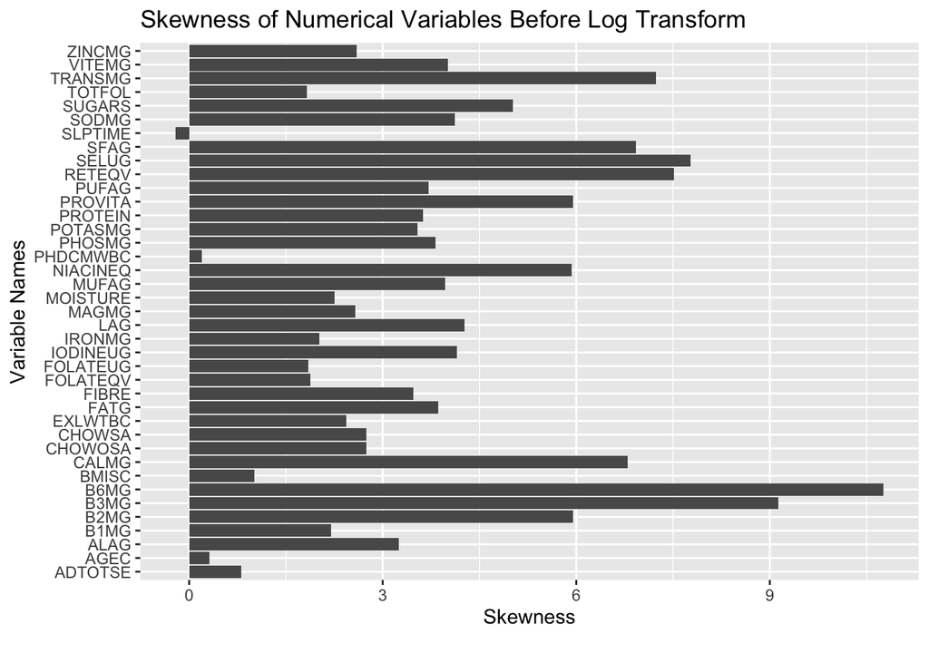

```r
# visualize skewness of data
skew_before_log <- sort(unlist(lapply(biom_food_cleaned %>% select_if(is.numeric), skewness)), decreasing = TRUE)
skew_before_log_df <- data.frame(variable = names(skew_before_log), skewness = unname(skew_before_log))
p_skew_before <- ggplot(data = skew_before_log_df, aes(x = variable, y = skewness)) +
  geom_bar(stat = "identity") +
  coord_flip() +
  labs( x = "Variable Names", y = "Skewness",
  title ="Skewness of Numerical Variables Before Log Transform",
  caption = "")
p_skew_before
```

```r
# log transformation
biom_food_log <- biom_food_cleaned %>% mutate_if(is.numeric, function(x){return (x + 1)}) %>% mutate_if(is.numeric, log)

# record mean and sd for later models (to be used in standardization)
biom_food_mean <- data.frame(unlist(lapply(biom_food_log %>% select_if(is.numeric), mean)))
biom_food_sd <- data.frame(unlist(lapply(biom_food_log %>% select_if(is.numeric), sd)))

biom_food_scaled <- biom_food_log %>% mutate_if(is.numeric, scale) # log transform and normalize

sum(unlist(lapply(biom_food_scaled %>% select_if(is.numeric), skewness)))
```

```
## [1] 45.37303
```

```r
# remove highly correlated variables
cor_90 <- findCorrelation(cor(biom_food_scaled %>% select_if(is.numeric)), names = TRUE)
biom_food_scaled <- biom_food_scaled %>% select(-all_of(cor_90))

# saving biom_food_scaled for future reference
save(biom_food_scaled, file = "combined_df.Rdata")
```

Completing the processing of data, we keep all the variables required for easy reference later on.

```r
# extract variables for each dataset for later use
food_vars <- intersect(colnames(food_gram_median), colnames(biom_food_cleaned))
biom_vars <- setdiff(colnames(biom_food_scaled), food_vars) # including cvd class
fra_vars <- c("AGEC", "SEX", "DIABBC", "SMKSTAT") # variables found in framingham score
```

## Analysis of Models’ Performances

With the data ready for analysis, we decided to try different models and evaluated their performances. Since our problem is a classification one and a supervised learning algorithm is needed, we applied the dataset to K-nearest neighbour, Support vector machine, Decision tree and Random forest. Additionally, due to large number of variables, we performed Boruta feature selection to choose variables that provide the most information to the models. This then reduces the issue of curse of dimensionality which can lead to overfitting.

We performed 10-fold cross validation to evaluate the different models with and without feature selection and compare their performances. The accuracy values of each fold are recorded and kept into a dataframe.

```r
set.seed(123) # set seed

cvK <- 10  # number of CV folds
X <- data.matrix(biom_food_scaled%>% select(-cvd_class))
y <- biom_food_scaled$cvd_class
cvSets <- cvTools::cvFolds(nrow(X), cvK)  # permute all the data, into 5 folds
boruta_knn <- boruta_svm <- boruta_rf <- boruta_tree <- full_knn <- full_svm <- full_rf <- full_tree <- fra_knn <- fra_svm <- fra_rf <- fra_tree<- NA  # initialise results vector
f1b_knn <- f1b_svm <- f1b_rf <- f1b_tree <- f1_knn <- f1_svm <- f1_rf <- f1_tree <- f1f_knn <- f1f_svm <- f1f_rf <- f1f_tree <- NA  # initialise results vector
rb_knn <- rb_svm <- rb_rf <- rb_tree <- r_knn <- r_svm <- r_rf <- r_tree <- rf_knn <- rf_svm <- rf_rf <- rf_tree <- NA  # initialise results vector
```

```r
# 10-fold cross validation (with and without boruta feature selection)
for (j in 1:cvK) {
  fold_time <-Sys.time()

  test_id <- cvSets$subsets[cvSets$which == j]
  X_test <- X[test_id, ]
  X_train <- X[-test_id, ]
  y_test <- y[test_id]
  y_train <- y[-test_id]

  # upsampling training set
  # X_train <- upSample(X_train, y_train, list = FALSE, yname = "y_train")
  # y_train <- X_train$y_train
  # X_train <- X_train %>% select(-y_train)

  # boruta subsets
  boruta <- Boruta(y_train~., data = data.frame(cbind(X_train, y_train)), maxRuns = 150, doTrace = 1)
  boruta_fixed <- TentativeRoughFix(boruta)
  boruta_vars <- getSelectedAttributes(boruta_fixed)
  boruta_train <- data.frame(X_train) %>% select(boruta_vars, all_of(fra_vars))
  boruta_test <- data.frame(X_test) %>% select(boruta_vars, all_of(fra_vars))

  fra_train <- data.frame(X_train) %>% select(all_of(fra_vars))
  fra_test <- data.frame(X_test) %>% select(all_of(fra_vars))

  # knn
  knn_model <- class::knn(train = boruta_train, test = boruta_test, cl = y_train)
  full_knn_model <- class::knn(train = X_train, test = X_test, cl = y_train)
  fra_knn_model <- class::knn(train = fra_train, test = fra_test, cl = y_train)

  # svm
  svm_model <- svm(
  x = data.matrix(boruta_train),
  y = y_train,
  type = "C",
  kernel = "radial")
  full_svm_model <- svm(
  x = data.matrix(X_train),
  y = y_train,
  type = "C",
  kernel = "radial")
  fra_svm_model <- svm(
  x = data.matrix(fra_train),
  y = y_train,
  type = "C",
  kernel = "radial")

  # random forest
  rf_model <- randomForest::randomForest(
  x = boruta_train,
  y = as.factor(y_train),
  random_state = 123
  )
  full_rf_model <- randomForest::randomForest(
  x = X_train,
  y = as.factor(y_train),
  random_state = 123
  )
  fra_rf_model <- randomForest::randomForest(
  x = fra_train,
  y = as.factor(y_train),
  random_state = 123
  )

  # decision tree
  tree_model <- rpart(y_train ~., data = data.frame(cbind(boruta_train, y_train)), method = "class", model = TRUE)
  full_tree_model <- rpart(y_train ~., data = data.frame(cbind(X_train, y_train)), method = "class", model = TRUE)
  fra_tree_model <- rpart(y_train ~., data = data.frame(cbind(fra_train, y_train)), method = "class", model = TRUE)

  boruta_tree[j] <-  table(predict(tree_model, boruta_test, type = "class"), y_test) %>% diag %>% sum %>% `/`(length(y_test))
  full_tree[j] <-  table(predict(full_tree_model,data.frame(X_test), type = "class"), y_test) %>% diag %>% sum %>% `/`(length(y_test))
  fra_tree[j] <-  table(predict(fra_tree_model,data.frame(fra_test), type = "class"), y_test) %>% diag %>% sum %>% `/`(length(y_test))

  boruta_knn[j] <- table(knn_model, y_test) %>% diag %>% sum %>% `/`(length(y_test))
  full_knn[j] <- table(full_knn_model, y_test) %>% diag %>% sum %>% `/`(length(y_test))
  fra_knn[j] <- table(fra_knn_model, y_test) %>% diag %>% sum %>% `/`(length(y_test))

  boruta_svm[j] <- table(predict(svm_model, data.matrix(boruta_test)), y_test) %>% diag %>% sum %>% `/`(length(y_test))
  full_svm[j] <- table(predict(full_svm_model, data.matrix(X_test)), y_test) %>% diag %>% sum %>% `/`(length(y_test))
  fra_svm[j] <- table(predict(fra_svm_model, data.matrix(fra_test)), y_test) %>% diag %>% sum %>% `/`(length(y_test))

  boruta_rf[j] <- table(predict(rf_model, boruta_test), y_test) %>% diag %>% sum %>% `/`(length(y_test))
  full_rf[j] <- table(predict(full_rf_model, X_test), y_test) %>% diag %>% sum %>% `/`(length(y_test))
  fra_rf[j] <- table(predict(fra_rf_model, fra_test), y_test) %>% diag %>% sum %>% `/`(length(y_test))


  f1b_knn[j] <- F1_Score(y_test, knn_model)
  f1b_svm[j] <- F1_Score(y_test, predict(svm_model, data.matrix(boruta_test)))
  f1b_rf[j] <- F1_Score(y_test, predict(rf_model, boruta_test))
  f1b_tree[j] <- F1_Score(y_test, predict(tree_model, boruta_test, type = "class"))

  f1_knn[j] <- F1_Score(y_test, full_knn_model)
  f1_svm[j] <- F1_Score(y_test, predict(full_svm_model, data.matrix(X_test)))
  f1_rf[j] <- F1_Score(y_test, predict(full_rf_model, X_test))
  f1_tree[j] <- F1_Score(y_test, predict(full_tree_model, data.frame(X_test), type = "class"))

  f1f_knn[j] <- F1_Score(y_test, fra_knn_model)
  f1f_svm[j] <- F1_Score(y_test, predict(fra_svm_model, data.matrix(fra_test)))
  f1f_rf[j] <- F1_Score(y_test, predict(fra_rf_model, fra_test))
  f1f_tree[j] <- F1_Score(y_test, predict(fra_tree_model, fra_test, type = "class"))


  rb_knn[j] <- Recall(y_test, knn_model)
  rb_svm[j] <- Recall(y_test, predict(svm_model, data.matrix(boruta_test)))
  rb_rf[j] <- Recall(y_test, predict(rf_model, boruta_test))
  rb_tree[j] <- Recall(y_test, predict(tree_model, boruta_test, type = "class"))

  r_knn[j] <- Recall(y_test, full_knn_model)
  r_svm[j] <- Recall(y_test, predict(full_svm_model, data.matrix(X_test)))
  r_rf[j] <- Recall(y_test, predict(full_rf_model, X_test))
  r_tree[j] <- Recall(y_test, predict(full_tree_model, data.frame(X_test), type = "class"))

  rf_knn[j] <- Recall(y_test, fra_knn_model)
  rf_svm[j] <- Recall(y_test, predict(fra_svm_model, data.matrix(fra_test)))
  rf_rf[j] <- Recall(y_test, predict(fra_rf_model, fra_test))
  rf_tree[j] <- Recall(y_test, predict(fra_tree_model, fra_test, type = "class"))

  print(paste("--", j, " fold finished for", j, "repeat in", as.numeric(Sys.time() - fold_time), "secs"))
}

# saving the accuracy, recall and f1 values from 10-fold cross validation for different models
save(full_knn, full_svm, full_rf, full_tree, boruta_knn, boruta_svm, boruta_rf, boruta_tree, fra_knn, fra_svm, fra_rf, fra_tree,
     f1_knn, f1_svm, f1_rf, f1_tree, f1b_knn, f1b_svm, f1b_rf, f1b_tree, f1f_knn, f1f_svm, f1f_rf, f1f_tree,
     r_knn, r_svm, r_rf, r_tree, rb_knn, rb_svm, rb_rf, rb_tree, rf_knn, rf_svm, rf_rf, rf_tree,
     file = "10_fold_res.Rdata")
```

Then, we saved the different score of these different models and the two best-performing models separately as tables into csv files. These files are used in python to generate visualisations.

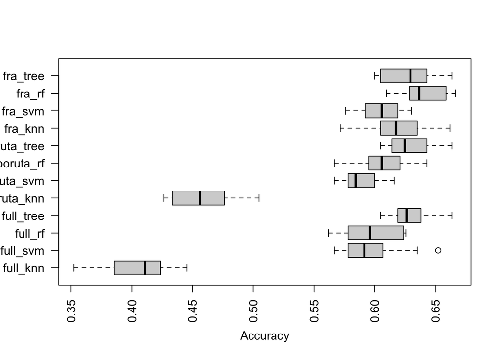

```r
# load file containing scores from 10-fold CV
load("10_fold_res.Rdata")

# boxplot of different models' accuracy
boxplot(full_knn, full_svm, full_rf, full_tree, boruta_knn, boruta_svm, boruta_rf, boruta_tree, fra_knn, fra_svm, fra_rf, fra_tree, names = c("full_knn", "full_svm", "full_rf", "full_tree", "boruta_knn", "boruta_svm", "boruta_rf", "boruta_tree", "fra_knn", "fra_svm", "fra_rf", "fra_tree"), las = 2, horizontal = TRUE, xlab = "Accuracy")
```

```r
# saving the accuracy values separately as tables
tibble(full_knn, full_svm, full_rf, full_tree, boruta_knn, boruta_svm, boruta_rf, boruta_tree) %>%
write_csv("tmp1.csv")

# saving F1 score and recall for decision tree and random forest
tibble(f1_rf, f1_tree) %>% write_csv("tmp2.csv")
tibble(r_rf, r_tree) %>% write_csv("tmp3.csv")
```

Given that the accuracy of the models are not excellent, we also tried other versions of the two models: random forest and desion tree. The three versions are differentiated by the dataset applied to the models. We tried the performances with dataset containing only variables found in the risk score, then with full dataset containing age, sex, status variables, diet and lifestyle variables, lastly with dataset containing variables selected by Boruta feature selection. A graph of boxplots of the three versions of the two models is also drawn to compare the accuracies further. Later on, a table is produced to present the numbers of the scores more clearly (included in report).

```r
# mean of accuracy of different versions of random forest
c(mean(fra_rf), mean(full_rf), mean(boruta_rf))
```

```
## [1] 0.6397224 0.5978944 0.6064432
```

```r
# mean of accuracy of different versions of decision tree
c(mean(fra_tree), mean(full_tree), mean(boruta_tree))
```

```
## [1] 0.6292620 0.6302257 0.6292688
```

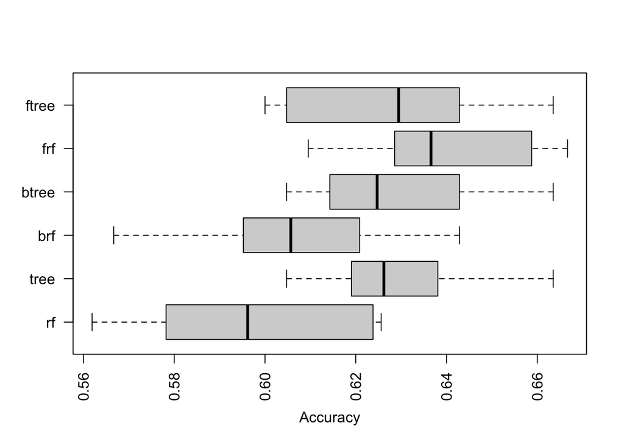

```r
# boxplot comparing different versions of random forest and decision tree
boxplot(full_rf, full_tree, boruta_rf, boruta_tree, fra_rf, fra_tree, names = c("rf", "tree", "brf", "btree", "frf", "ftree"), las = 2, horizontal = TRUE, xlab = "Accuracy")
```

## Building final model (decision tree) with Boruta feature selection

```r
# selecting variables using Boruta feature selection and saving the result
boruta_result <- Boruta(cvd_class~., data = biom_food_scaled, maxRuns = 500, doTrace = 1)
save(boruta_result, file = "borutaresult.Rdata")
```

```r
# load file containing boruta feature selection result
load("borutaresult.Rdata")

# obtaining variables selected from Boruta
boruta_final_fixed <- TentativeRoughFix(boruta_result)
boruta_final_vars <- getSelectedAttributes(boruta_final_fixed)
```

```r
# checking number of variables selected
length(boruta_final_vars)
```

```
## [1] 26
```

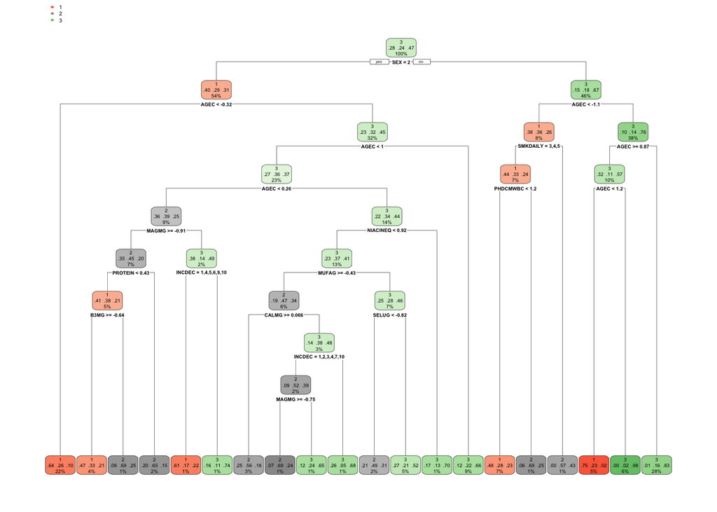

```r
# split dataset into training and test set
X <- data.matrix(biom_food_scaled%>% select(-cvd_class))
y <- biom_food_scaled$cvd_class
test_id <- cvSets$subsets[cvSets$which == 1]

X_test <- X[test_id, ]
X_train <- X[-test_id, ]
y_test <- y[test_id]
y_train <- y[-test_id]

# train and test model with selected variables
boruta_train <- data.frame(X_train) %>% select(boruta_final_vars, all_of(fra_vars))
boruta_test <- data.frame(X_test) %>% select(boruta_final_vars, all_of(fra_vars))

# build decision tree
tree_model <- rpart(cvd_class ~., data = biom_food_scaled %>% select(boruta_final_vars, cvd_class), method = "class", model = TRUE, control = rpart.control(cp=0.005))
rpart.plot(tree_model)
```

To get a better idea of the process, the model and the variables, we have done several visualisations which are included in the folder named **figures**. The visualisations are created using different techniques and platforms so they are all included in the folder readily used. We have drawn a flowchart to present the whole process (one for data preprocessing and one for model training) of our analysis. Then, the table of variables selected and their importance is created to have a better understanding of how they impact the response variable in the decision tree. A confusion matrix is also plotted to show how well the model predicts each class. We have also included a **vis.ipynb** file in the figures folder that include visualisations done with the help of python which has been converted into **vis.rmd** to facilitate the code reading in R. Lastly, we also have the decision tree drawn for better interpretation and understand how the tree does the classification process.

We have also included the file where we did some manual calculations to obtain the original values of the variables instead of the scaled ones in the rule of decision tree. The file is named **Variable Conversion Table.xlsx**.